# POLI 178 - Final Project R Code

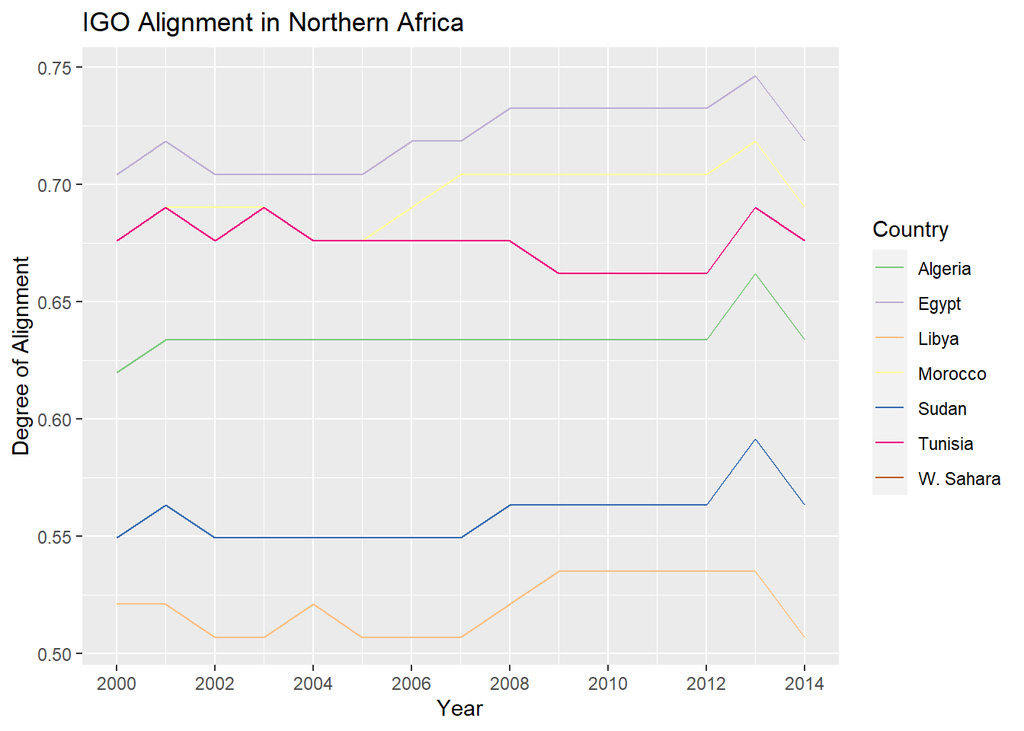

```r
# North Africa and China IGO Alignment
ggplot(IGO_geo_NAfrica, aes(x = Year, y = IGO.Alignment, color = name)) +
  geom_line() +
  scale_color_manual(values = col_vector, name = "Country") +
  scale_x_continuous(breaks=seq(2000, 2014, 2)) +
  labs(title = "IGO Alignment in Northern Africa", x = "Year", y = "Degree of Alignment")
```

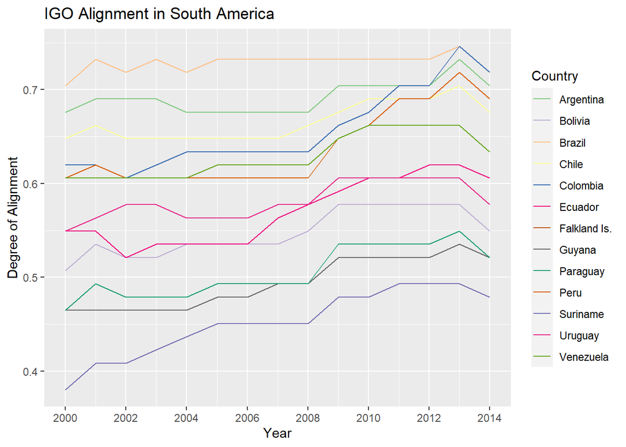

```r
# South America and China IGO Alignment
ggplot(IGO_geo_SAmerica, aes(x = Year, y = IGO.Alignment, color = name)) +
  geom_line() +
  scale_color_manual(values = col_vector, name = "Country") +
  scale_x_continuous(breaks=seq(2000, 2014, 2)) +
  labs(title = "IGO Alignment in South America", x = "Year", y = "Degree of Alignment")
```

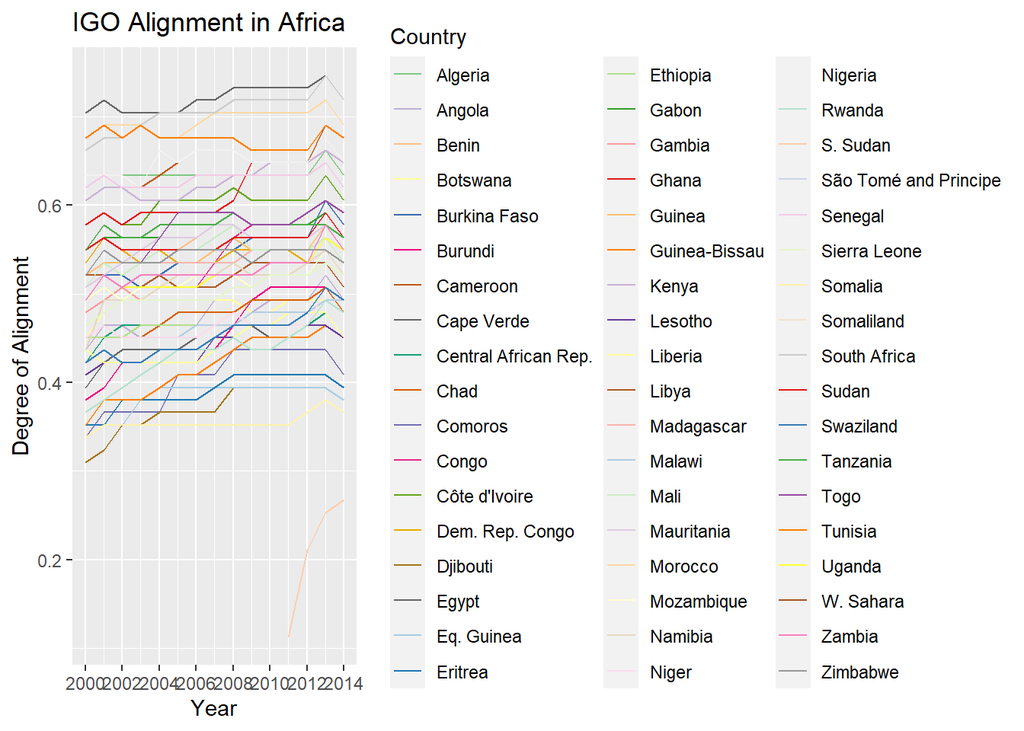

```r
# Africa and China IGO Alignment
ggplot(IGO_geo_Africa, aes(x = Year, y = IGO.Alignment, color = name)) +
  geom_line() +
  scale_color_manual(values = col_vector, name = "Country") +
  scale_x_continuous(breaks=seq(2000, 2014, 2)) +
  labs(title = "IGO Alignment in Africa", x = "Year", y = "Degree of Alignment")
```

Now we can look at analyses.

```r
# averages across all years for each country in South America in new dataframe
avg_SAmerica_IGO <- IGO_geo_SAmerica  %>%
  st_drop_geometry() %>%
  group_by(name) %>%
  summarise_at(vars(IGO.Alignment), list(name = mean))
avg_SAmerica_IGO <- data.frame(unique(IGO_geo_SAmerica$name), avg_SAmerica_IGO)
colnames(avg_SAmerica_IGO) <- c("Country", "Average Alignment")
avg_SAmerica_IGO[!is.na(avg_SAmerica_IGO$`Average Alignment`),]
```

```
##      Country Average Alignment
## 1  Argentina         0.6920188
## 2    Bolivia         0.5474178
## 3     Brazil         0.7286385
## 4      Chile         0.6657277
## 5   Colombia         0.6563380
## 6    Ecuador         0.5699531
## 8     Guyana         0.4938967
## 9       Peru         0.5051643
## 10  Paraguay         0.6375587
## 11  Suriname         0.4516432
## 12   Uruguay         0.5812207
## 13 Venezuela         0.6291080
```

```r
# averages across all years for each country in Africa in new dataframe
avg_Africa_IGO <- IGO_geo_Africa  %>%
  st_drop_geometry() %>%
  group_by(name) %>%
  summarise_at(vars(IGO.Alignment), list(name = mean))
avg_Africa_IGO <- data.frame(unique(IGO_geo_Africa$name), avg_Africa_IGO)
colnames(avg_Africa_IGO) <- c("Country", "Average Alignment")
avg_Africa_IGO[!is.na(avg_Africa_IGO$`Average Alignment`),]
```

```
##                 Country Average Alignment
## 1                Angola         0.6347418
## 2               Burundi         0.4779343
## 3                 Benin         0.5549296
## 4          Burkina Faso         0.4863850
## 5              Botswana         0.5446009
## 6  Central African Rep.         0.4525822
## 7         Côte d'Ivoire         0.6488263
## 8              Cameroon         0.4460094
## 9       Dem. Rep. Congo         0.4619718
## 10                Congo         0.4769953
## 11              Comoros         0.4037559
## 12           Cape Verde         0.5417840
## 13             Djibouti         0.6018779
## 14              Algeria         0.5408451
```

[output cut: 37 more lines]

## Polity

```r
# look at table for summary of polity for 2000 to 2018
table(polity$Polity)
```

```
##
## -10  -9  -8  -7  -6  -5  -4  -3  -2  -1   0   1   2   3   4   5   6   7   8   9
##  69  59  47 193  90  40 112 101  95  71  80  28  54  61  88 168 255 199 327 308
##  10
## 648
```

```r
sum(is.na(polity$Polity))
```

```
## [1] 46
```

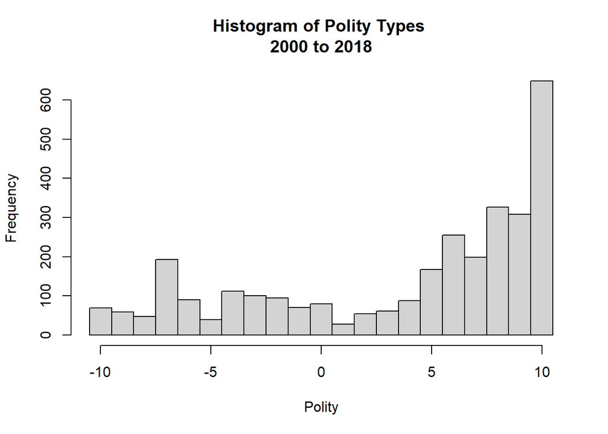

```r
# histogram
hist(polity$Polity, breaks = -10.5:10.5, xlab = 'Polity', ylab = 'Frequency',
     main = 'Histogram of Polity Types \n2000 to 2018')
```

```r
# now look at polity in 2018
polity2018 <- subset(polity, Year == 2018)
table(polity2018$Polity)
```

```
##
## -10  -9  -8  -7  -6  -5  -4  -3  -2  -1   0   1   2   3   4   5   6   7   8   9
##   4   3   3   8   3   1   7   7   5   3   3   1   2   3   6   8  12  17  18  18
##  10
##  33
```

```r
sum(is.na(polity2018$Polity))
```

```
## [1] 1
```

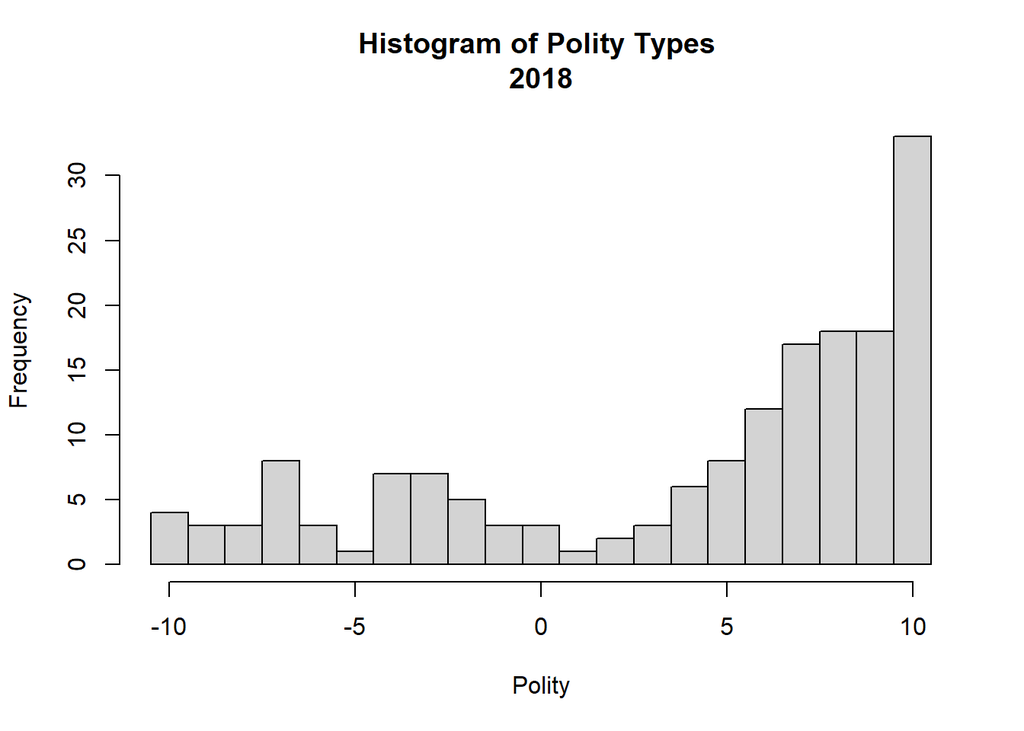

```r
hist(polity2018$Polity, breaks = -10.5:10.5, xlab = 'Polity', ylab = 'Frequency',
     main = 'Histogram of Polity Types \n2018')
```

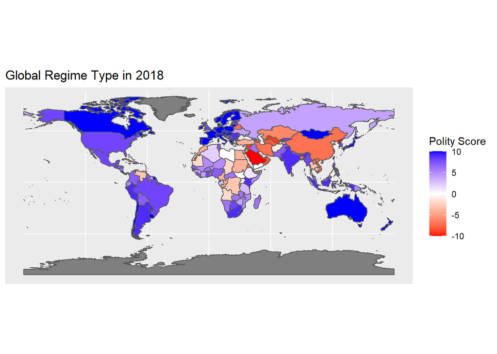

```r
# geospatial in 2018
polity_geo <- merge(world, polity2018, by.x = "iso_a3", by.y = "Code", all.x = TRUE)

ggplot(data=polity_geo, aes(fill = Polity)) +
  scale_fill_gradientn(colours = c("red", "white", "blue"),
                       name = "Polity Score") +
  geom_sf() + ggtitle("Global Regime Type in 2018")
```

## GDP

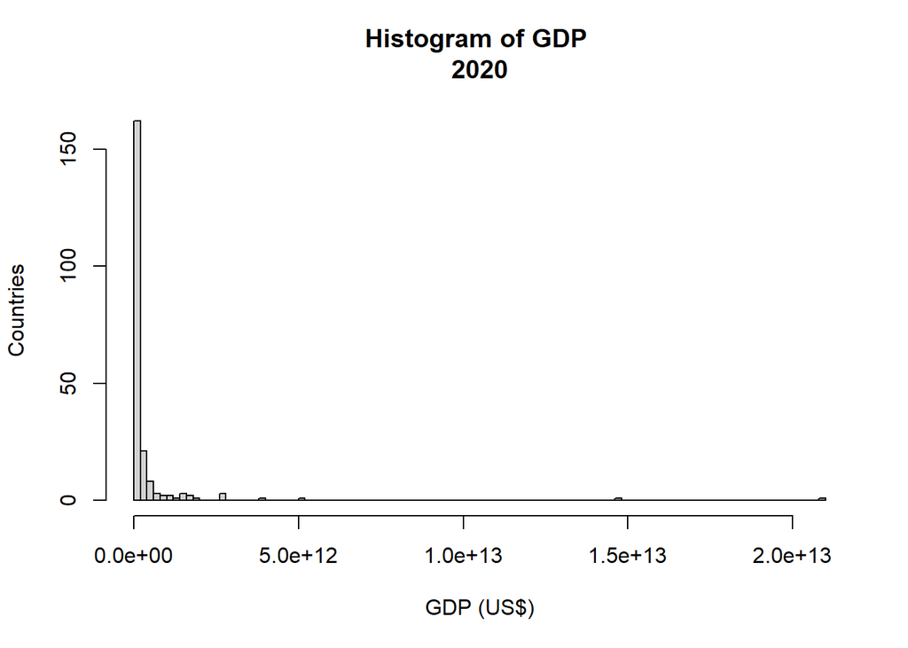

```r
# look at GDP in 2020
hist(GDP_2020$GDP, breaks = 100, xlab = 'GDP (US$)', ylab = 'Countries',
     main = 'Histogram of GDP \n2020')
```

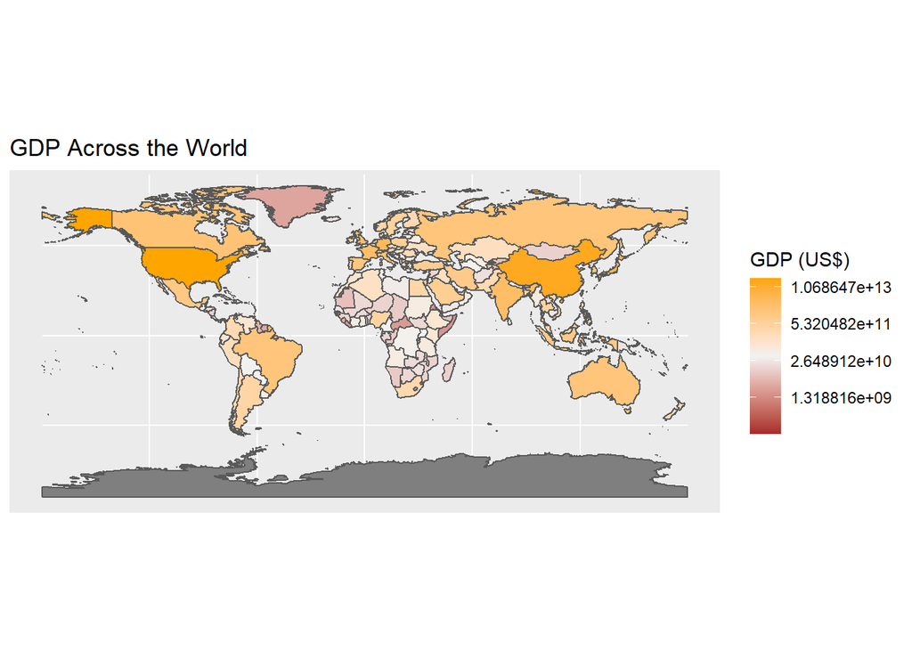

```r
# most countries clustered strongly to the left,
# but there are a handful of very productive countries

# geospatial
GDP_geo <- merge(world, GDP_2020, by.x = "iso_a3", by.y = "Code", all.x = TRUE)

ggplot(data=GDP_geo, aes(fill = GDP)) +
  scale_fill_gradientn(colours = c("brown", "gray95", "orange"), trans = "log",
                       name = "GDP (US$)") +
  geom_sf() + ggtitle("GDP Across the World")
```

## Resources

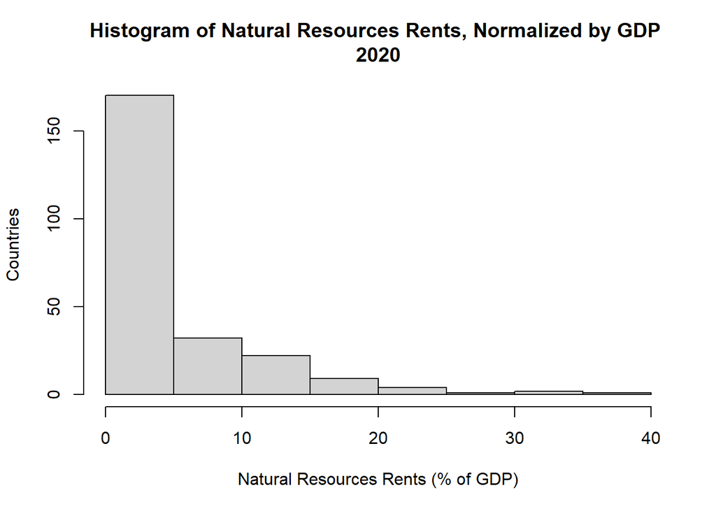

```r
# look at resources (% of GDP) in 2020
resources_2020 <- resources %>% subset(Year == 2020)

hist(resources_2020$Resources, xlab = 'Natural Resources Rents (% of GDP)', ylab = 'Countries',
     main = 'Histogram of Natural Resources Rents, Normalized by GDP \n2020')
```

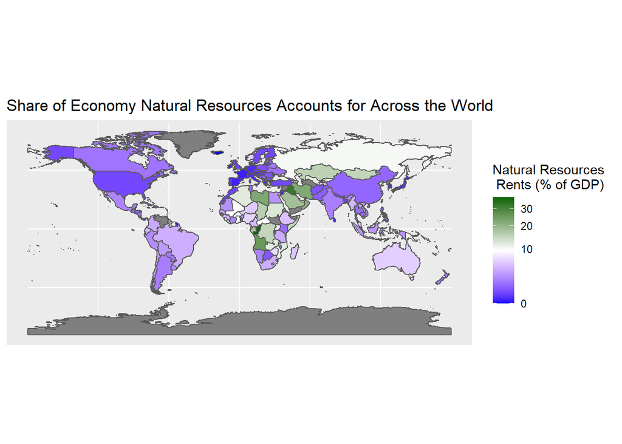

```r
# geospatial
resources_geo <- merge(world, resources_2020, by.x = "iso_a3", by.y = "Code", all.x = TRUE)

ggplot(data=resources_geo, aes(fill = Resources)) +
  scale_fill_gradientn(colours = c("blue", "white", "darkgreen"), trans = "sqrt",
                       name = "Natural Resources \n Rents (% of GDP)") +
  geom_sf() + ggtitle("Share of Economy Natural Resources Accounts for Across the World")
```

# Competitive ML

## Preliminaries

```r
# setting seed
set.seed(42)
```

Now we need to deal with missingness in data. We use one rule of thumb: if the GDP doesn’t exist, data are likely insufficient for the model.

```r
df <- df[!is.na(df$GDP),]
```

Polity only lasts to 2018, but we will assume the polity stays the same to 2020.

```r
country_list <- unique(df$Code)
for (i in country_list) {
  polity2018 <- df$Polity[which(df$Code == i & df$Year == "2018")]
  df$Polity[which(df$Code == i & (df$Year == "2019" | df$Year == "2020"))] <- polity2018
}
```

Missing data for arms imports, arms exports, imports, and exports can be considered $0. We assume missing data for resources means 0 of GDP is accounted by natural resources. We also assume that because missing polity indicates foerign intervention, the regime is neither democratic nor autocratic (0 for polity).

```r
columns_to_fill <- c("Arms.Imports","Arms.Exports","Imports","Exports","Resources","Polity")
df[,columns_to_fill] <- df[,columns_to_fill] %>% replace(is.na(.), 0)
```

However, arms data is too militarily based and pretty sparse. IGO alignment is much too sparse and difficult to interpolate. Financial diplomacy only lasts to 2017, and it is hard to make future predictions. We will remove all of these from our dataframe.

```r
df <- df %>% select(-c("Arms.Imports","Arms.Exports","IGO.Alignment","Fin.Diplomacy"))
```

```r
#### difficult to interpolate HDI, drop rows with NA HDI
df_econ <- df %>% filter(Year >= 2005 & Year < 2020) %>% select(-"UN.Agreement")
df_econ <- df_econ[!(is.na(df_econ$FDI) | is.na(df_econ$HDI)),]

df_dipl <- df %>% filter(Year < 2020) %>% select(-"FDI")
df_dipl <- df_dipl[!(is.na(df_dipl$UN.Agreement) | is.na(df_dipl$HDI)),]

### splitting data, 80-20 split
econ_splitter = initial_split(df_econ, prop = 0.8)
econ_train_data = training(econ_splitter)
econ_test_data = testing(econ_splitter)

dipl_splitter = initial_split(df_dipl, prop = 0.8)
dipl_train_data = training(dipl_splitter)
dipl_test_data = testing(dipl_splitter)

### recipe pre-processing
econ_rcp <- recipe(FDI~.,data = econ_train_data) %>%
  step_dummy(all_nominal(),-FDI) %>%
  step_range(all_numeric(),-FDI) %>%
  prep()

dipl_rcp <- recipe(UN.Agreement~.,data = dipl_train_data) %>%
  step_dummy(all_nominal(),-UN.Agreement) %>%
  step_range(all_numeric(),-UN.Agreement) %>%
  prep()

### bake with recipes
baked_econ_train_data <- bake(econ_rcp,econ_train_data)
baked_econ_test_data <- bake(econ_rcp,econ_test_data)

baked_dipl_train_data <- bake(dipl_rcp,dipl_train_data)
baked_dipl_test_data <- bake(dipl_rcp,dipl_test_data)

### use 10 k-folds
econ_folds <- createFolds(baked_econ_train_data$FDI, k = 10)
dipl_folds <- createFolds(baked_dipl_train_data$UN.Agreement, k = 10)

### validation conditions
econ_val_cond <- trainControl(method='cv', index = econ_folds)
dipl_val_cond <- trainControl(method='cv', index = dipl_folds)
```

## Linear Regression

```r
econ_mod_lm <- train(FDI ~ ., data=baked_econ_train_data, method = "lm",
                     metric = "RMSE", trControl = econ_val_cond)
dipl_mod_lm <- train(UN.Agreement ~ ., data=baked_dipl_train_data, method = "lm",
                     metric = "RMSE", trControl = dipl_val_cond)
```

## KNN

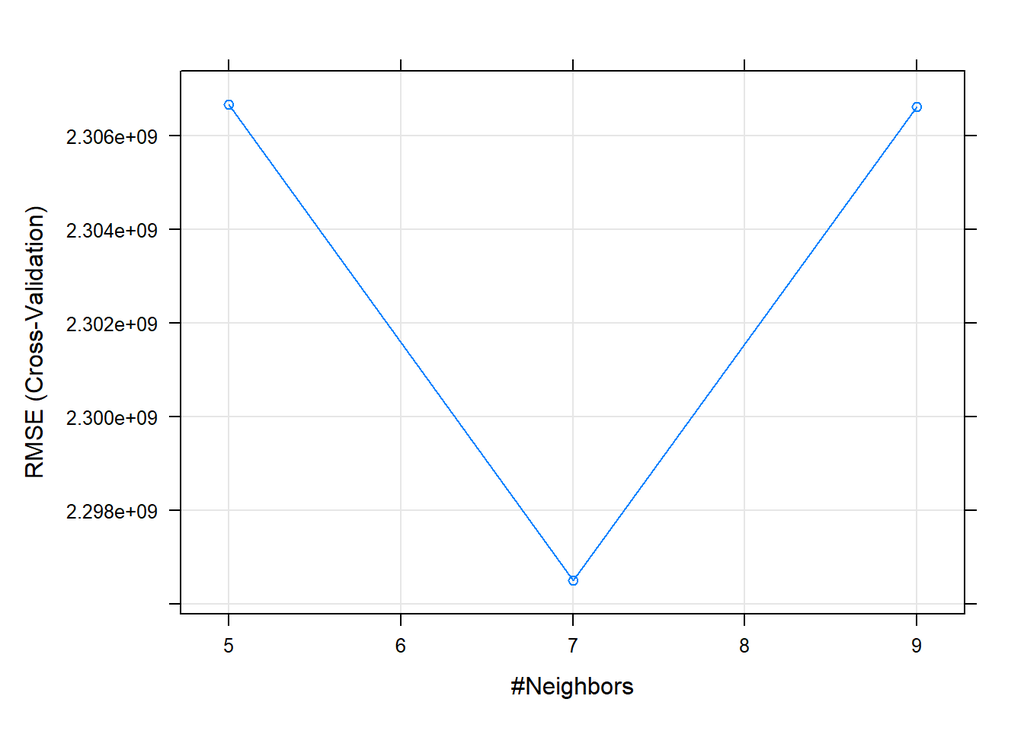

```r
econ_mod_knn <- train(FDI ~ ., data=baked_econ_train_data, method = "knn",
                      metric = "RMSE", trControl = econ_val_cond)

dipl_mod_knn <- train(UN.Agreement ~ ., data=baked_dipl_train_data, method = "knn",
                     metric = "RMSE", trControl = dipl_val_cond)

# plot KNN RMSE
plot(econ_mod_knn)
```

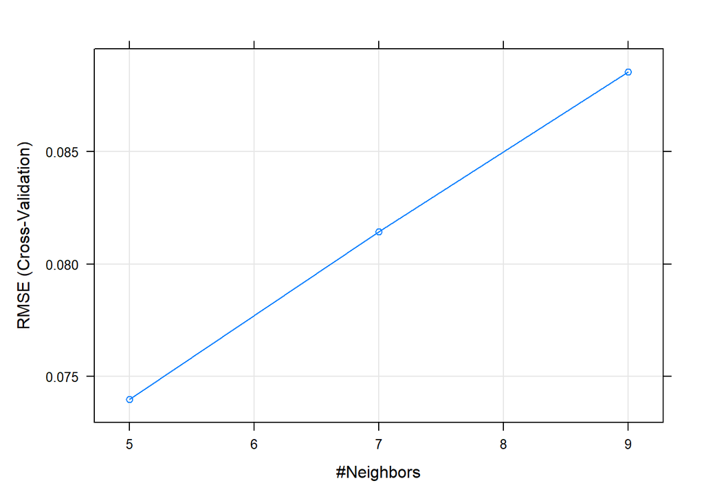

```r
plot(dipl_mod_knn)
```

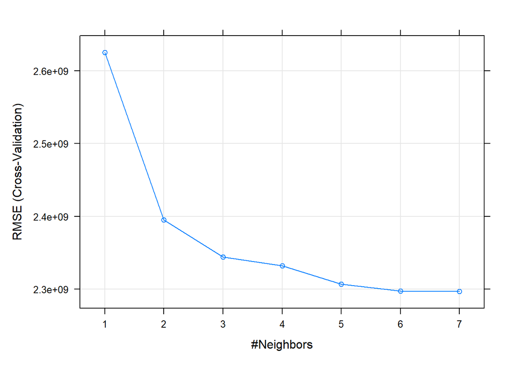

```r
# try lower k = 1:7
knn_tune = expand.grid(k = 1:7)
econ_mod_knn2 <- train(FDI ~ ., data=baked_econ_train_data, method = "knn",
                       metric = "RMSE", trControl = econ_val_cond, tuneGrid = knn_tune)

dipl_mod_knn2 <- train(UN.Agreement ~ ., data=baked_dipl_train_data, method = "knn",
                       metric = "RMSE", trControl = dipl_val_cond, tuneGrid = knn_tune)

# plot tuned KNN RMSE
plot(econ_mod_knn2) # minimum at k = 7
```

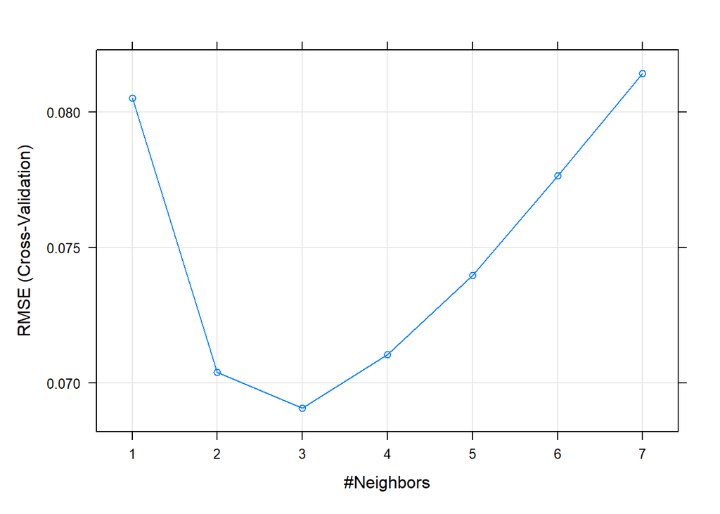

```r
plot(dipl_mod_knn2) # minimum at k = 3
```

## Decision Trees

```r
econ_mod_cart <- train(FDI ~ ., data=baked_econ_train_data, method = "rpart",
                       metric = "RMSE", trControl = econ_val_cond)
dipl_mod_cart <- train(UN.Agreement ~ ., data=baked_dipl_train_data, method = "rpart",
                      metric = "RMSE", trControl = dipl_val_cond)
```

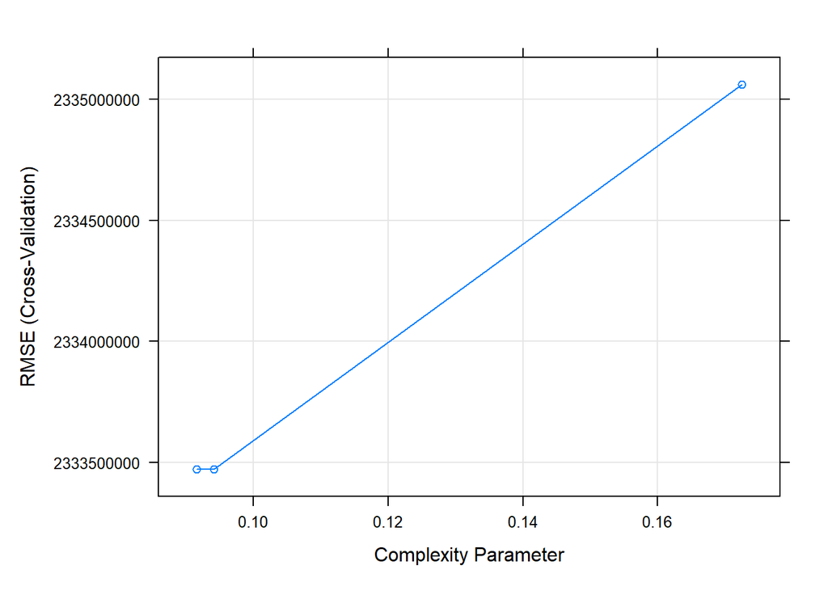

```r
# plot decision trees RMSE
plot(econ_mod_cart)
```

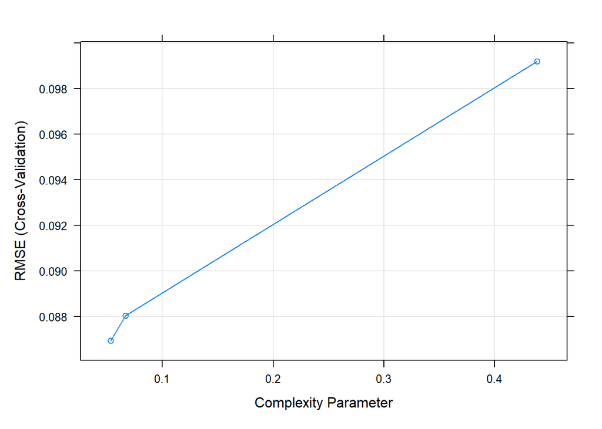

```r
plot(dipl_mod_cart)
```

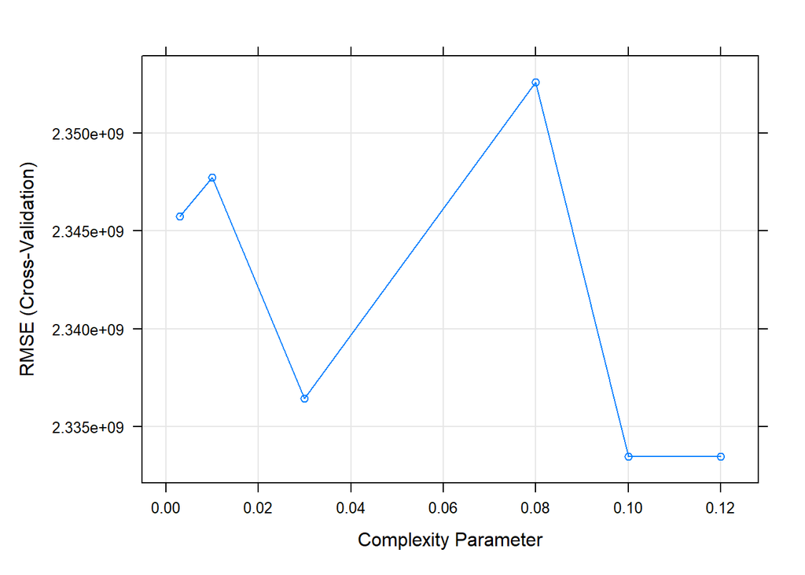

```r
# try lower alpha value
tune_cart <- expand.grid(cp = c(0.003, 0.01, 0.03, 0.08, 0.1, 0.12))

econ_mod_cart2 <- train(FDI ~ ., data=baked_econ_train_data, method = "rpart",
                       metric = "RMSE", trControl = econ_val_cond, tuneGrid = tune_cart)

dipl_mod_cart2 <- train(UN.Agreement ~ ., data=baked_dipl_train_data, method = "rpart",
                       metric = "RMSE", trControl = dipl_val_cond, tuneGrid = tune_cart)

plot(econ_mod_cart2) # minimum at alpha = 0.12
```

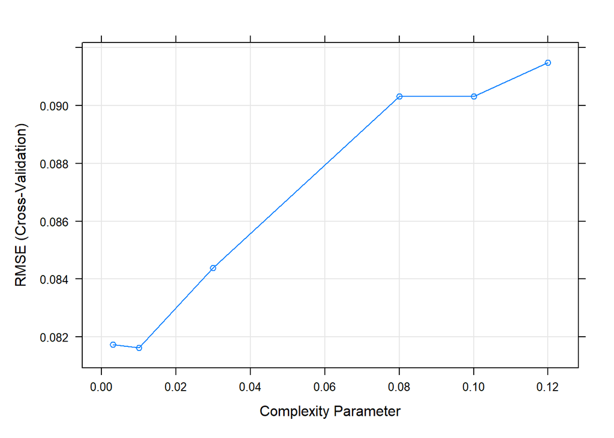

```r
plot(dipl_mod_cart2) # minimum at alpha = 0.01
```

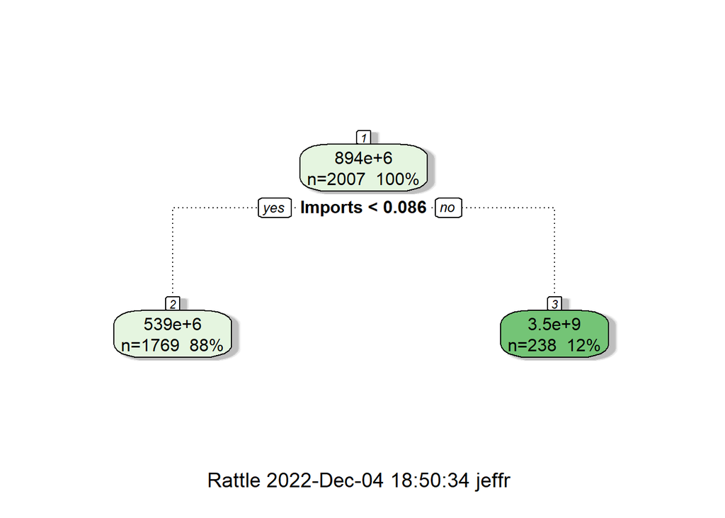

```r
# plot decision trees
fancyRpartPlot(econ_mod_cart2$finalModel)
```

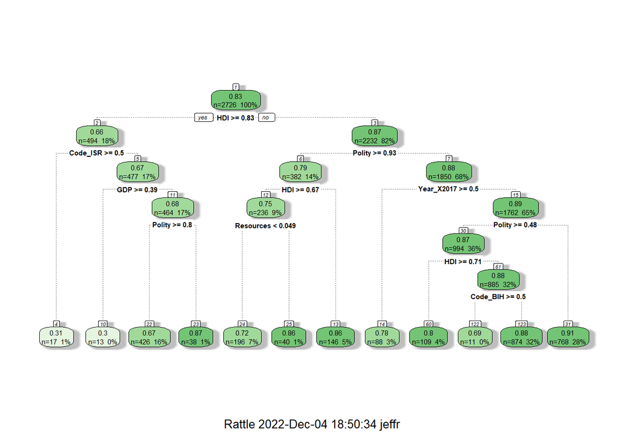

```r
fancyRpartPlot(dipl_mod_cart2$finalModel)
```

## Random Forest

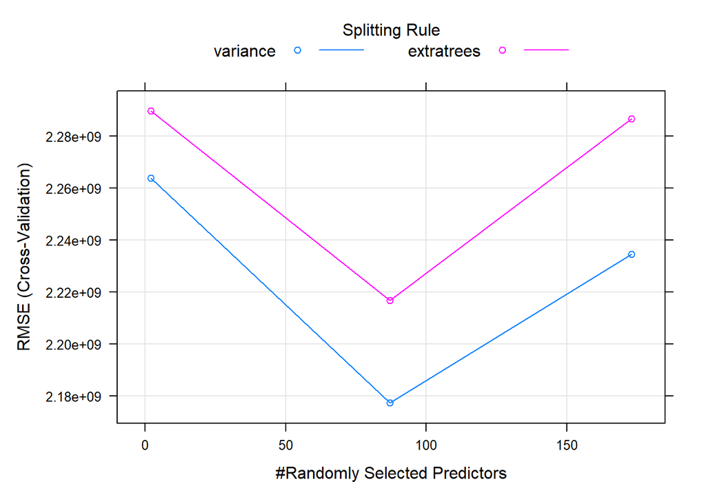

```r
econ_mod_rf <- train(FDI ~ ., data=baked_econ_train_data, method = "ranger",
                       metric = "RMSE", trControl = econ_val_cond)

dipl_mod_rf <- train(UN.Agreement ~ ., data=baked_dipl_train_data, method = "ranger",
                       metric = "RMSE", trControl = dipl_val_cond)

plot(econ_mod_rf) # minimum at 87
```

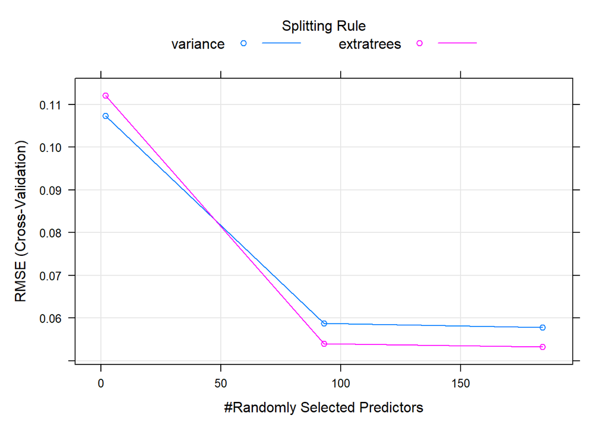

```r
plot(dipl_mod_rf) # minimum at 184
```

## Comparison

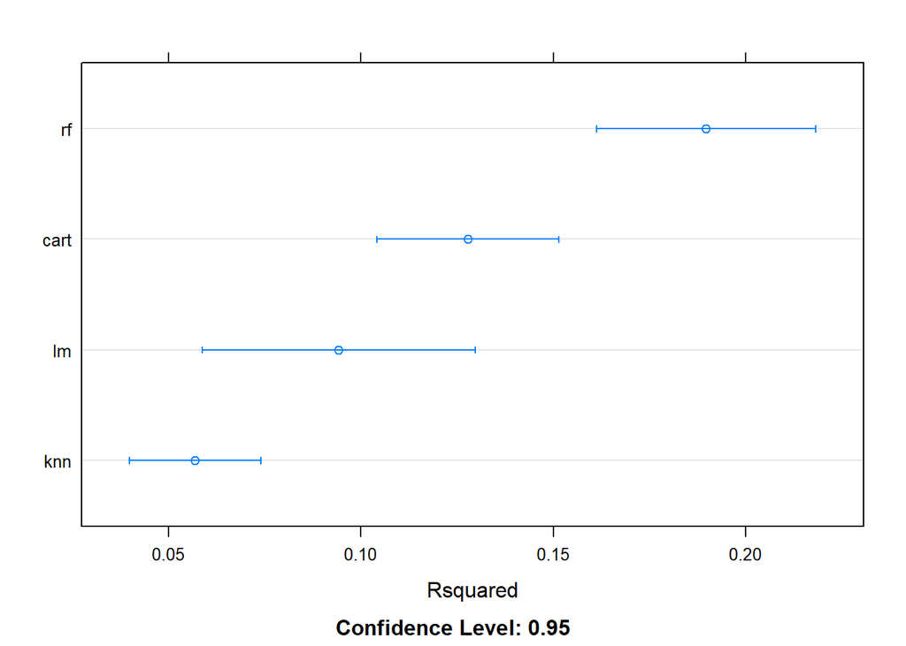

```r
econ_mod_list <- list(lm = econ_mod_lm, knn = econ_mod_knn2,
                      cart = econ_mod_cart2, rf = econ_mod_rf)

dipl_mod_list <- list(lm = dipl_mod_lm, knn = dipl_mod_knn2,
                      cart = dipl_mod_cart2, rf = dipl_mod_rf)

# resampling
dotplot(resamples(econ_mod_list),metric = "Rsquared") # random forest does best
```

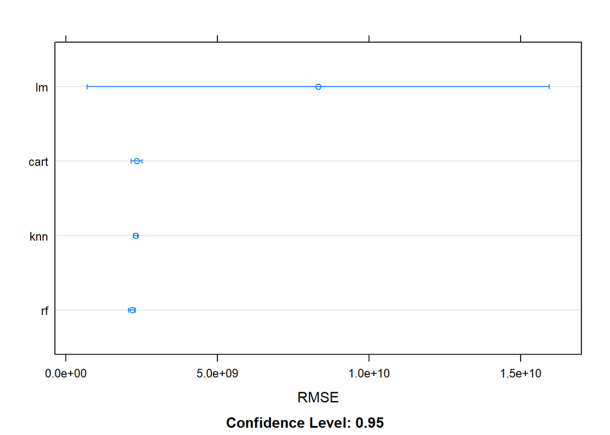

```r
dotplot(resamples(econ_mod_list),metric = "RMSE") # random forest does best
```

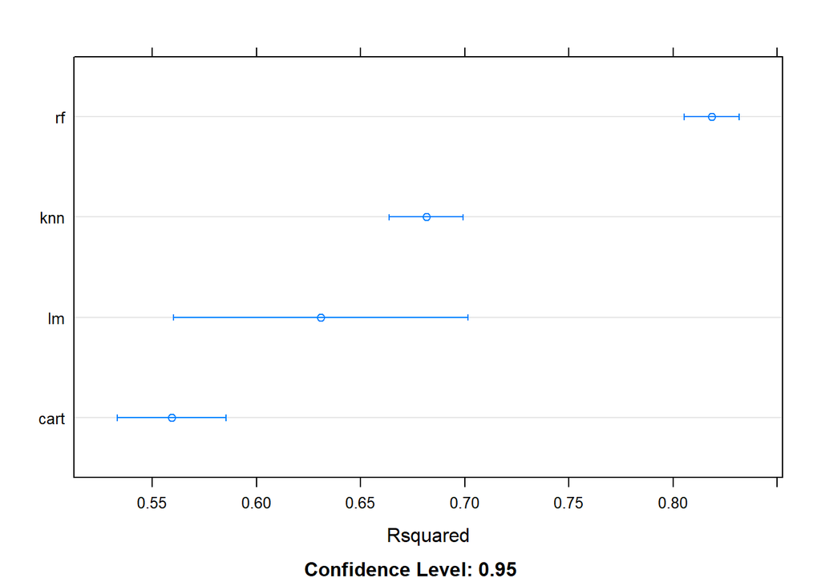

```r
dotplot(resamples(dipl_mod_list),metric = "Rsquared") # random forest does best
```

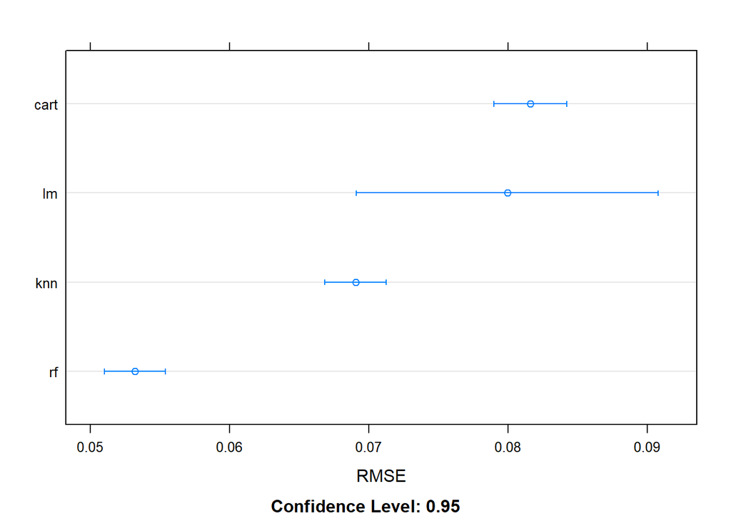

```r
dotplot(resamples(dipl_mod_list),metric = "RMSE") # random forest does best
```

We see that the random forest model performs the best for the economic and diplomatic model, as well as for both the $R^2$ and RMSE metrics. We will use the random forest model on our testing data.

```r
# input testing data
econ_pred_rf <- predict(econ_mod_rf, newdata = baked_econ_test_data)
dipl_pred_rf <- predict(dipl_mod_rf, newdata = baked_dipl_test_data)

# compare actual to prediction
econ_perf <- tibble(truth=baked_econ_test_data$FDI, estimate = econ_pred_rf)
dipl_perf <- tibble(truth=baked_dipl_test_data$UN.Agreement, estimate = dipl_pred_rf)

econ_perf_table <- bind_rows(econ_perf %>% rmse(truth,estimate), econ_perf %>% rsq(truth,estimate))
econ_perf_table
```

```
## # A tibble: 2 × 3
##   .metric .estimator .estimate
##   <chr>   <chr>          <dbl>
## 1 rmse    standard     2.11e+9
## 2 rsq     standard     5.31e-1
```

```r
dipl_perf_table <- bind_rows(dipl_perf %>% rmse(truth,estimate), dipl_perf %>% rsq(truth,estimate))
dipl_perf_table
```

```
## # A tibble: 2 × 3
##   .metric .estimator .estimate
##   <chr>   <chr>          <dbl>
## 1 rmse    standard      0.0349
## 2 rsq     standard      0.934
```

## Prediction Using 2020 Data

The latest year we have all data for is 2020. We will use this set of data to predict into the future.

```r
# get data
df_2020 <- df %>% filter(Year == 2020) %>% select(-c("UN.Agreement","FDI"))

# bake 2020 data
baked_econ_2020 <- bake(econ_rcp,df_2020) %>% replace(is.na(.),0)
baked_dipl_2020 <- bake(dipl_rcp,df_2020) %>% replace(is.na(.),0)
# predict
econ_pred_2020 <- predict(econ_mod_rf, baked_econ_2020)
dipl_pred_2020 <- predict(dipl_mod_rf, baked_dipl_2020)
df_2020$FDI.Pred <- econ_pred_2020
df_2020$UN.Agreement.Pred <- dipl_pred_2020

# set China to NA (doesn't make sense to have soft power with itself)
df_2020$FDI.Pred[which(df_2020$Code == "CHN")] <- NA
df_2020$UN.Agreement.Pred[which(df_2020$Code == "CHN")] <- NA

# normalize FDI with GDP
df_2020$FDI.Norm.Pred <- df_2020$FDI.Pred/df_2020$GDP
```

### Geospatial with Predictions

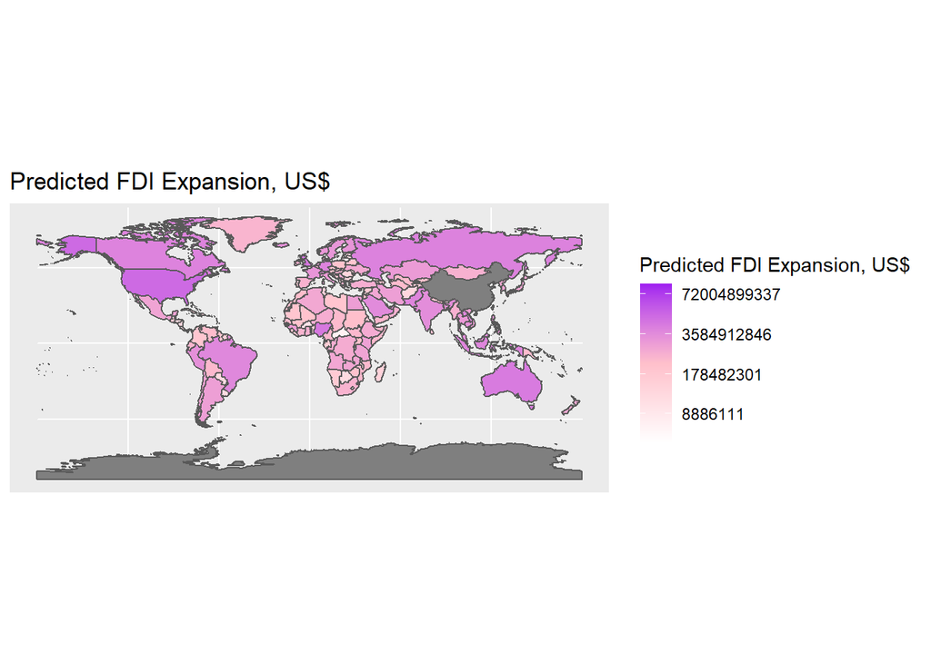

```r
world_pred <- merge(world, df_2020, by.x = "iso_a3", by.y = "Code", all.x = TRUE)

ggplot(data=world_pred, aes(fill = FDI.Pred)) +
  scale_fill_gradientn(limits = c(1*10^6,15*10^10),
                       colours = c("white", "pink", "purple"),
                       trans = "log",
                       name = "Predicted FDI Expansion, US$") +
  geom_sf() + ggtitle("Predicted FDI Expansion, US$")
```

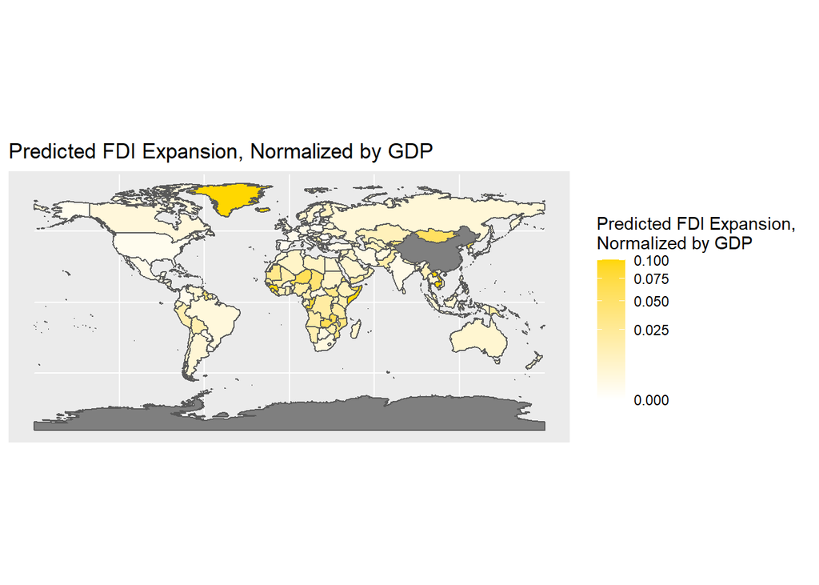

```r
# for better visualization of differences, cut off FDI.Norm.Pred > 0.1 to just 0.1
world_pred$FDI.Norm.Pred <- ifelse(world_pred$FDI.Norm.Pred > 0.1, 0.1, world_pred$FDI.Norm.Pred)

ggplot(data=world_pred, aes(fill = FDI.Norm.Pred)) +
  scale_fill_gradientn(limits = c(0,0.1),
                       colours = c("white", "gold"),
                       trans = "sqrt",
                       name = "Predicted FDI Expansion, \nNormalized by GDP") +
  geom_sf() + ggtitle("Predicted FDI Expansion, Normalized by GDP")
```

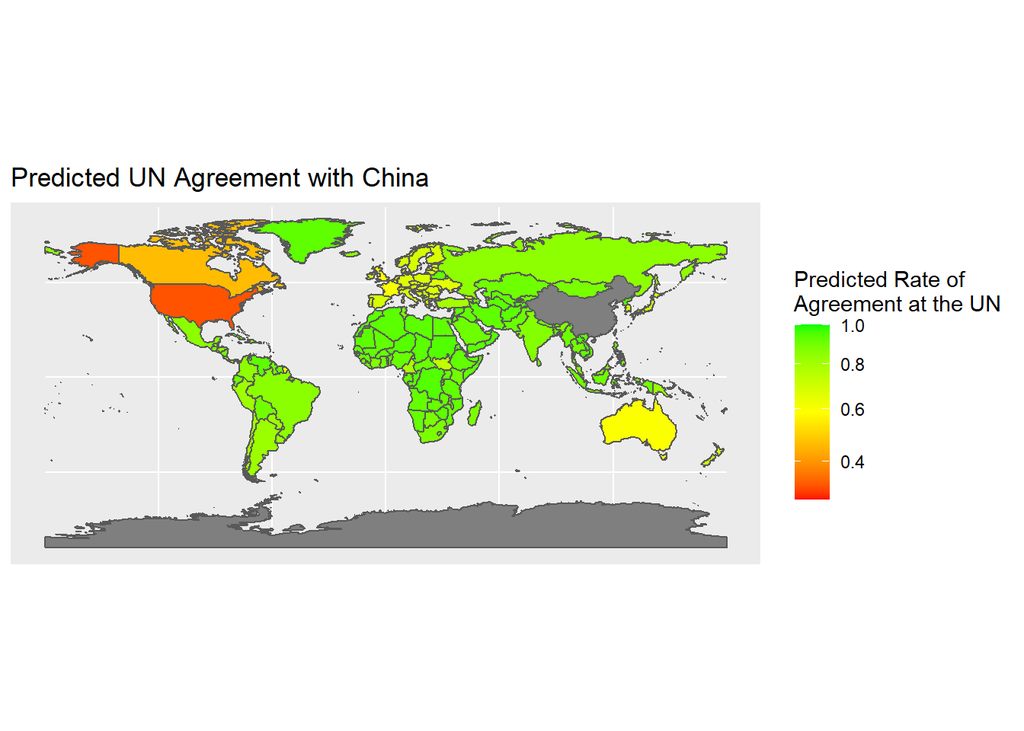

```r
ggplot(data=world_pred, aes(fill = UN.Agreement.Pred)) +
  scale_fill_gradientn(limits = c(0.28,1),
                       colours = c("red", "yellow", "green"),
                       trans = "sqrt",
                       name = "Predicted Rate of \nAgreement at the UN") +
  geom_sf() + ggtitle("Predicted UN Agreement with China")
```